# ProblemSet2

Hua Yang

2022-10-12

## GBA 5140 Statistics Essentials for Business Analytics

### Descriptive Statistics

Problem 1

Load “Data-MTCars.csv” into RStudio. Write R code for the following tasks. Post your R code and RStudio output (console output or plots output) below each task.

```r
setwd('/Users/xiaoqin/Documents/Business Analytics/5140/week6')
mtcars_df <- read.csv("Data-MTCars.csv")
head(mtcars_df)
```

```
##               model  mpg cyl disp  hp drat    wt  qsec vs am gear carb
## 1         Mazda RX4 21.0   6  160 110 3.90 2.620 16.46  0  1    4    4
## 2     Mazda RX4 Wag 21.0   6  160 110 3.90 2.875 17.02  0  1    4    4
## 3        Datsun 710 22.8   4  108  93 3.85 2.320 18.61  1  1    4    1
## 4    Hornet 4 Drive 21.4   6  258 110 3.08 3.215 19.44  1  0    3    1
## 5 Hornet Sportabout 18.7   8  360 175 3.15 3.440 17.02  0  0    3    2
## 6           Valiant 18.1   6  225 105 2.76 3.460 20.22  1  0    3    1
```

**1.Generate frequency distribution, relative frequency distribution, and percent frequency distribution for variable “cyl”.**

```r
cyl_freq <- mtcars_df %>%
  group_by(cyl)%>%
  summarise(n=n())%>%
  mutate(relative_freq=n / sum(n),percent_freq=(n/ sum(n)) * 100)
head(cyl_freq)
```

```
## # A tibble: 3 × 4
##     cyl     n relative_freq percent_freq
##   <int> <int>         <dbl>        <dbl>
## 1     4    11         0.344         34.4
## 2     6     7         0.219         21.9
## 3     8    14         0.438         43.8
```

**2.Draw bar chart and pie chart of variable “cyl”.**

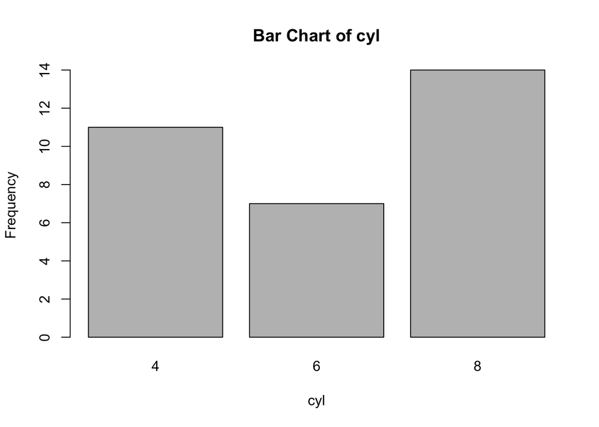

```r
barplot(cyl_freq$n, names.arg = cyl_freq$cyl,
        xlab = "cyl", ylab = "Frequency", main = "Bar Chart of cyl")
```

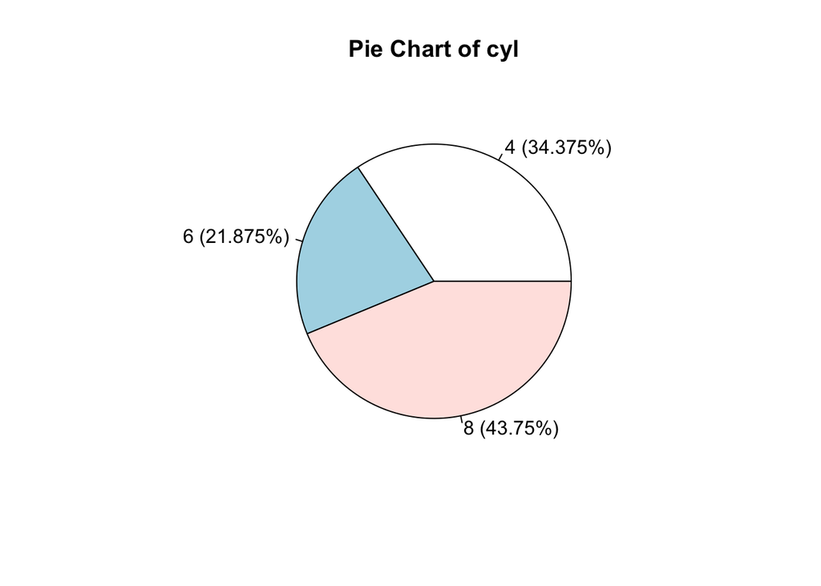

```r
pie(cyl_freq$n, main = "Pie Chart of cyl",
    labels = paste(cyl_freq$cyl, " (", cyl_freq$percent_freq, "%)", sep = ""))
```

**3.Determine the appropriate number of bins for variable “mpg” using Sturge’s method, and generate the corresponding frequency distribution, relative frequency distribution, percent frequency distribution, cumulative frequency distribution, cumulative relative frequency distribution, and cumulative percent distribution.**

```r
mpg_bin_num<-nclass.Sturges(mtcars_df$mpg)
mpg_bin <- cut(mtcars_df$mpg, mpg_bin_num)
mpg_freq <- data.frame(table(mpg_bin))
names(mpg_freq)[1] <- "mpg_freq"
mpg_freq$Rel_Freq <- mpg_freq$Freq / sum(mpg_freq$Freq)
mpg_freq$Pct_Freq <- 100.00 * mpg_freq$Rel_Freq
mpg_freq$Cum_Freq <- cumsum(mpg_freq$Freq)
mpg_freq$Cum_Rel_Freq <- cumsum(mpg_freq$Rel_Freq)
mpg_freq$Cum_Pct_Freq <- cumsum(mpg_freq$Pct_Freq)
mpg_freq
```

```
##      mpg_freq Freq Rel_Freq Pct_Freq Cum_Freq Cum_Rel_Freq Cum_Pct_Freq
## 1 (10.4,14.3]    4  0.12500   12.500        4      0.12500       12.500
## 2 (14.3,18.2]   10  0.31250   31.250       14      0.43750       43.750
## 3 (18.2,22.1]    9  0.28125   28.125       23      0.71875       71.875
## 4 (22.1,26.1]    4  0.12500   12.500       27      0.84375       84.375
## 5   (26.1,30]    1  0.03125    3.125       28      0.87500       87.500
## 6   (30,33.9]    4  0.12500   12.500       32      1.00000      100.000
```

**4.Draw histogram of variable “mpg”.**

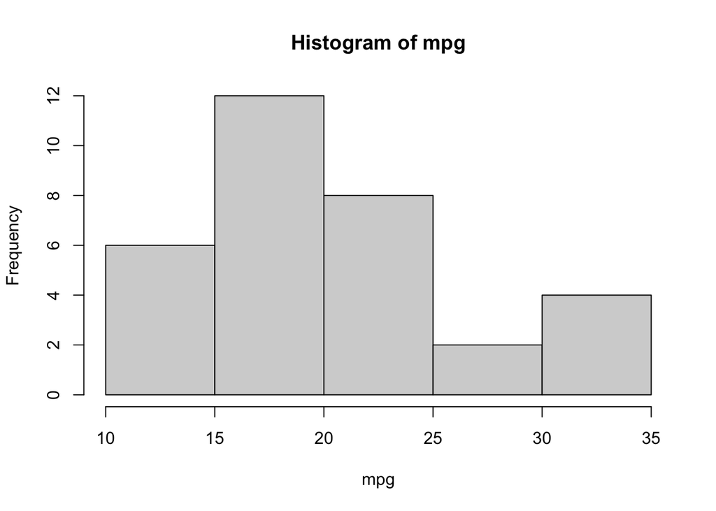

```r
hist(mtcars_df$mpg,xlab = "mpg",
     main = "Histogram of mpg")
```

**5.Determine the appropriate number of bins for variable “mpg” using Sturge’s method, then generate crosstabulation for variables “mpg” and “gear”.**

```r
mpg_bin_num<-nclass.Sturges(mtcars_df$mpg)
mtcars_df$mpg_bin <- cut(mtcars_df$mpg, mpg_bin_num)
mtcars_df$gear <-factor(mtcars_df$gear,levels = c("3", "4", "5"))
mtcars_freq <-table(mtcars_df$mpg_bin, mtcars_df$gear)
mtcars_freq
```

```
##
##               3 4 5
##   (10.4,14.3] 4 0 0
##   (14.3,18.2] 7 1 2
##   (18.2,22.1] 4 4 1
##   (22.1,26.1] 0 3 1
##   (26.1,30]   0 1 0
##   (30,33.9]   0 3 1
```

**6.Draw scatter chart using variables “mpg” (as horizontal axis) and “hp” (as vertical axis), then add the trendline.**

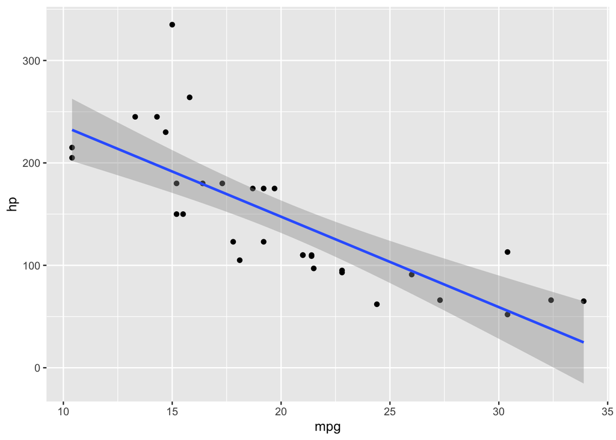

```r
ggplot(data=mtcars_df,aes(x=mpg,y=hp))+
  geom_point()+
  geom_smooth(method="lm")
```

**7.Compute mean, median, minimum, maximum, range, variance, and standard deviation of variable “hp”.**

```r
hp_sta <-mtcars_df%>%
  summarise(ave_hp=mean(hp),
            med_hp=median(hp),
            min_hp=min(hp),
            max_hp=max(hp),
            range_hp=(max(hp)-min(hp)),
            variance_hp=var(hp),
            std_hp=sd(hp))
hp_sta
```

```
##     ave_hp med_hp min_hp max_hp range_hp variance_hp   std_hp
## 1 146.6875    123     52    335      283    4700.867 68.56287
```

**8.Compute covariance and correlation coefficient between variables “mpg” and “hp”.**

```r
print(paste("Covariance:", cov(mtcars_df$mpg, mtcars_df$hp)))
```

```
## [1] "Covariance: -320.732056451613"
```

```r
print(paste("Correlation coefficient:", cor(mtcars_df$mpg, mtcars_df$hp)))
```

```
## [1] "Correlation coefficient: -0.776168371826586"
```